# lab8

Ayimen H.

2025-03-11

## 1. Taste of cheddar cheese

```r
library(readxl)
cheese_data <- read_excel("cheese.xls")
```

### (a) Write code to construct three scatter plots showing the relationship

between the response variable and each of the three predictor variables. For each scatter plot, also find the corresponding sample correlation coefficient value, r.

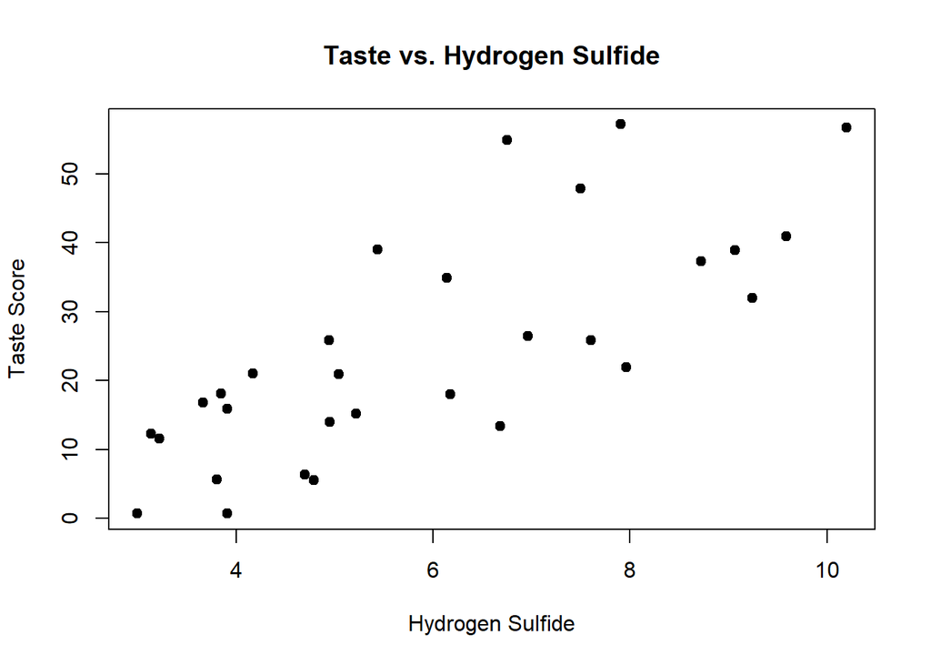

```r
plot(cheese_data$H2S, cheese_data$taste, main = "Taste vs. Hydrogen Sulfide",
     xlab = "Hydrogen Sulfide", ylab = "Taste Score", pch = 19)
```

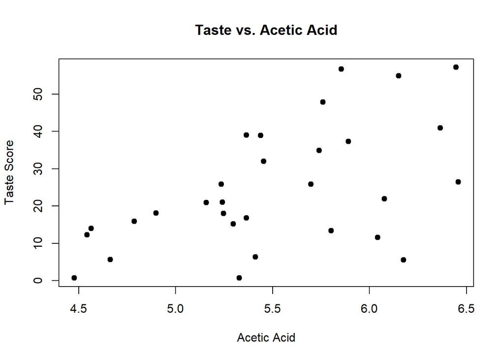

```r
plot(cheese_data$Acetic, cheese_data$taste, main = "Taste vs. Acetic Acid",
     xlab = "Acetic Acid", ylab = "Taste Score", pch = 19)
```

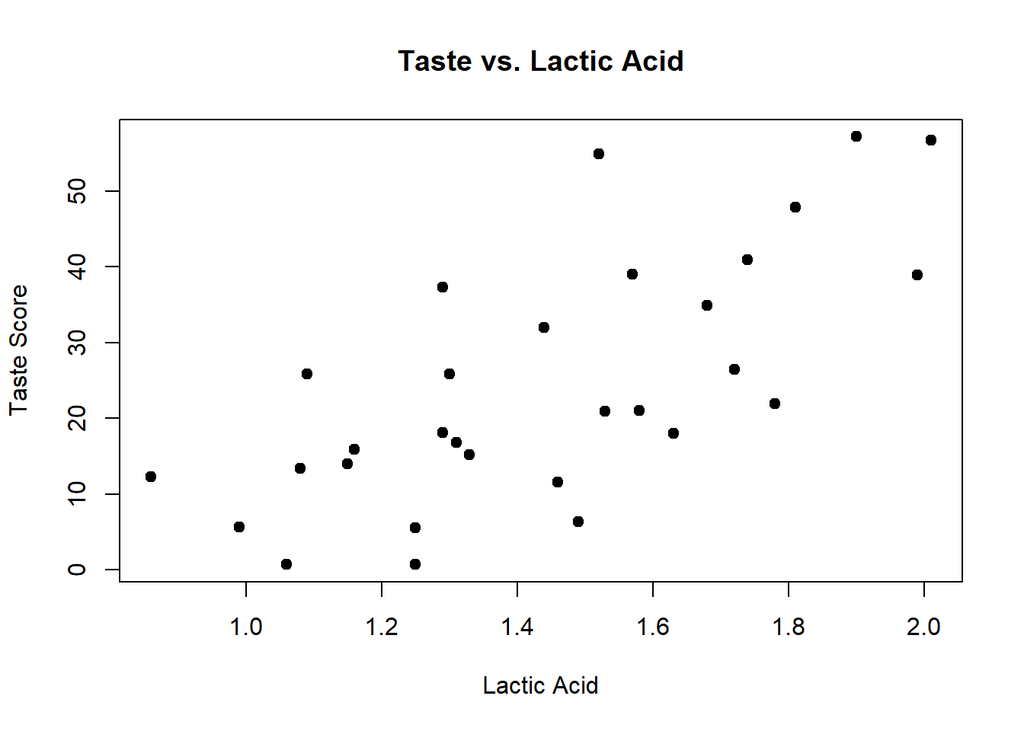

```r
plot(cheese_data$Lactic, cheese_data$taste, main = "Taste vs. Lactic Acid",
     xlab = "Lactic Acid", ylab = "Taste Score", pch = 19)
```

```r
cor_h2s <- cor(cheese_data$H2S, cheese_data$taste)
cor_acetic <- cor(cheese_data$Acetic, cheese_data$taste)
cor_lactic <- cor(cheese_data$Lactic, cheese_data$taste)

cat("r for Hydrogen Sulfide and Taste:", round(cor_h2s, 4), "\n")
```

```
## r for Hydrogen Sulfide and Taste: 0.7558
```

```r
cat("r for Acetic Acid and Taste:", round(cor_acetic, 4), "\n")
```

```
## r for Acetic Acid and Taste: 0.5495
```

```r
cat("r for Lactic Acid and Taste:", round(cor_lactic, 4), "\n")
```

```
## r for Lactic Acid and Taste: 0.7042
```

Based on the scatter plots and correlation coefficients, there seems to be a relationship between all variables and the taste score. The strongest relationship with taste score is hydrogen sulfide as it has the highest correlation coefficient

### (b) Find the equation of the regression line predicting taste score based on

hydrogen sulfide level. What taste score would you predict for a cheese whose hydrogen sulfide measurement was 5.0?

```r
h2s_reg <- lm(formula = taste ~ H2S, data = cheese_data)
intercept <- h2s_reg$coefficients[[1]]
slope <- h2s_reg$coefficients[[2]]

cat("Regression equation: Taste = ", round(intercept, 4), "+", round(slope, 4),
    "× Hydrogen Sulfide\n")
```

```
## Regression equation: Taste =  -9.7868 + 5.7761 × Hydrogen Sulfide
```

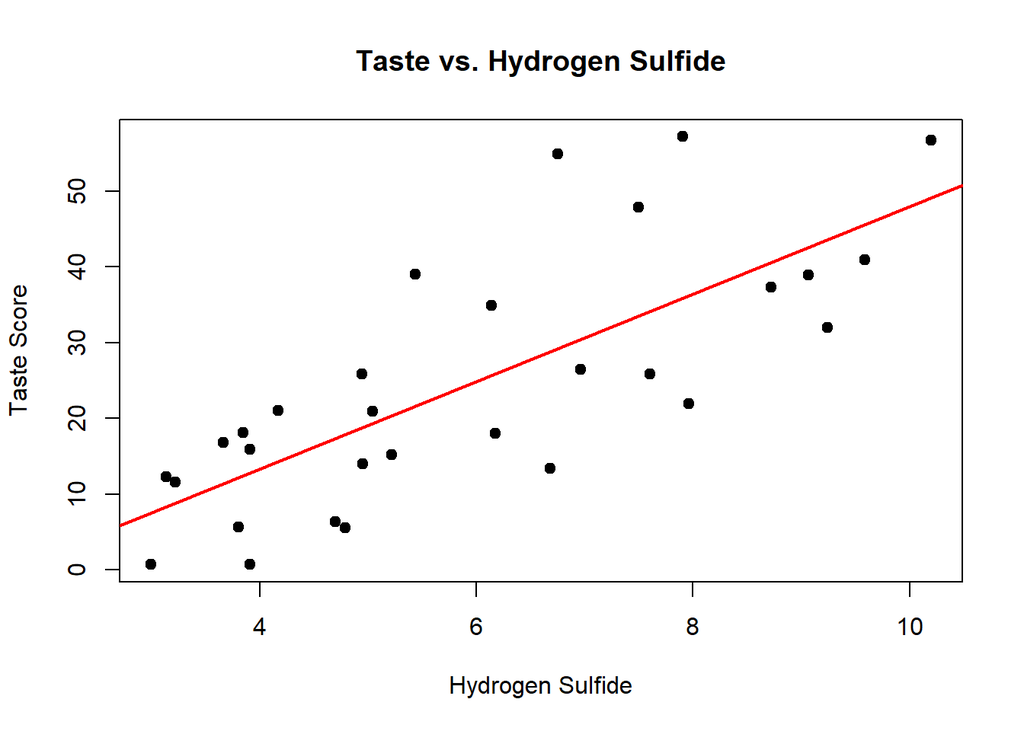

```r
plot(cheese_data$H2S, cheese_data$taste, main = "Taste vs. Hydrogen Sulfide",
     xlab = "Hydrogen Sulfide", ylab = "Taste Score", pch = 19)

abline(h2s_reg, col = "red", lwd = 2)
```

```r
predicted_taste <- intercept + slope * 5.0
cat("Taste score for hydrogen sulfide = 5.0: ", round(predicted_taste, 4))
```

```
## Taste score for hydrogen sulfide = 5.0:  19.0936
```

### (c) Write code to find the value of the coefficient of determination, r2, for

the regression model predicting taste rating based on hydrogen sulfide levels. In your own words, explain what this r2 value tells you about the quality of the regression model.

```r
r_squared <- summary(h2s_reg)$r.squared
cat("Coefficient of determination (r^2):", round(r_squared, 4), "\n")
```

```
## Coefficient of determination (r^2): 0.5712
```

### (d) Write code to estimate the equation of the regression line predicting

taste score based on all three predictor variables in a single equation. Based on your regression equation, what taste score would you predict for a cheese whose hydrogen sulfide measurement was 5.0, whose acetic acid measurement was 6.1, and whose lactic acid measurement was 0.90? Also, based on the output from the statistical software, what proportion of the variability in taste scores can be explained by this model using all three predictor variables?

```r
multi_reg <- lm(formula = taste ~ H2S + Acetic + Lactic, data = cheese_data)
summary(multi_reg)
```

```
##
## Call:
## lm(formula = taste ~ H2S + Acetic + Lactic, data = cheese_data)
##
## Residuals:
##     Min      1Q  Median      3Q     Max
## -17.390  -6.612  -1.009   4.908  25.449
##
## Coefficients:
##             Estimate Std. Error t value Pr(>|t|)
## (Intercept) -28.8768    19.7354  -1.463  0.15540
## H2S           3.9118     1.2484   3.133  0.00425 **
## Acetic        0.3277     4.4598   0.073  0.94198
## Lactic       19.6705     8.6291   2.280  0.03108 *
## ---
## Signif. codes:  0 '***' 0.001 '**' 0.01 '*' 0.05 '.' 0.1 ' ' 1
##
## Residual standard error: 10.13 on 26 degrees of freedom
## Multiple R-squared:  0.6518, Adjusted R-squared:  0.6116
## F-statistic: 16.22 on 3 and 26 DF,  p-value: 3.81e-06
```

```r
multi_intercept <- multi_reg$coefficients[[1]]

multi_h2s <- multi_reg$coefficients[[2]]
multi_acetic <- multi_reg$coefficients[[3]]
multi_lactic <- multi_reg$coefficients[[4]]

cat("Multiple regression equation:\n")
```

```
## Multiple regression equation:
```

```r
cat("Taste = ", round(multi_intercept, 4), "+", round(multi_h2s, 4), "× H2S +",
    round(multi_acetic, 4), "× Acetic +", round(multi_lactic, 4), "× Lactic\n")
```

```
## Taste =  -28.8768 + 3.9118 × H2S + 0.3277 × Acetic + 19.6705 × Lactic
```

```r
new_data <- data.frame(H2S = 5.0, Acetic = 6.1, Lactic = 0.90)

predicted_taste_multi <- predict(multi_reg, newdata = new_data)
cat("Predicted taste score for H2S = 5.0, Acetic = 6.1, and Lactic = 0.90: ",
    round(predicted_taste_multi, 4), "\n")
```

```
## Predicted taste score for H2S = 5.0, Acetic = 6.1, and Lactic = 0.90:  10.3851
```

```r
multi_r_squared <- summary(multi_reg)$r.squared
cat("Proportion of variability explained (R^2): ", round(multi_r_squared, 4), "\n")
```

```
## Proportion of variability explained (R^2):  0.6518
```

## 2. Polyester rope failure

First, let’s read in the ropes data.

```r
ropes_data <- read.delim("ropes.txt", sep = " ", header = FALSE)
names(ropes_data) <- c("Load", "Time")
```

### (a) Construct a scatter plot of x = load versus y = time. Would it be

reasonable to characterize the relationship between the two variables as linear?

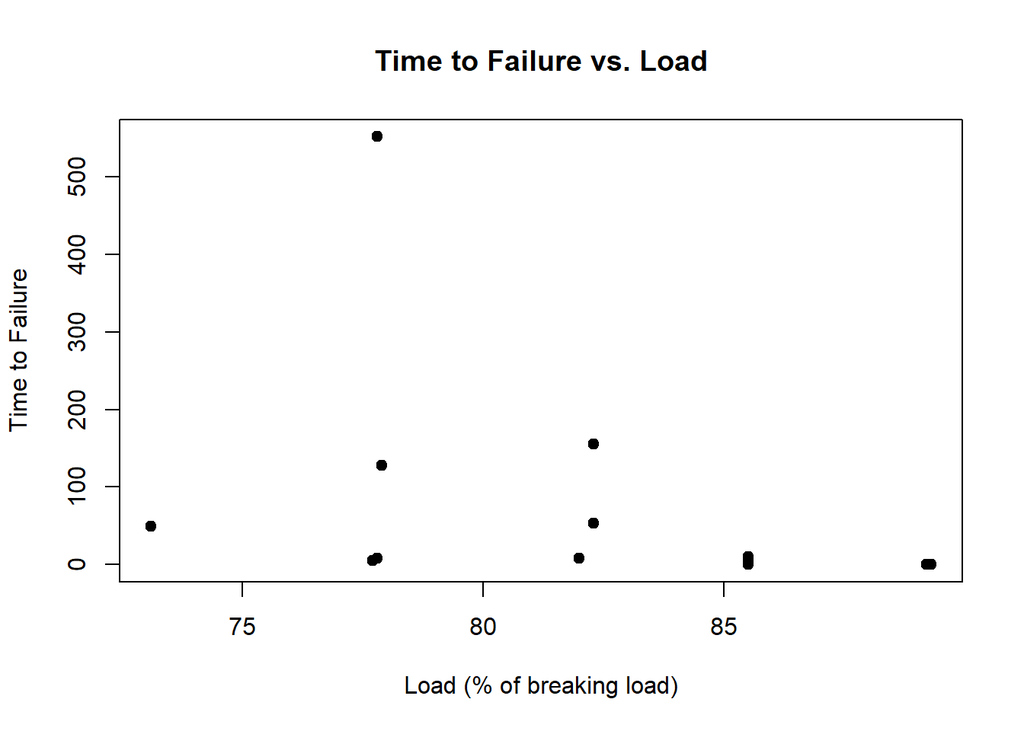

```r
plot(ropes_data$Load, ropes_data$Time, main = "Time to Failure vs. Load",
     xlab = "Load (% of breaking load)", ylab = "Time to Failure",
     pch = 19)
```

Assuming I plotted it right the relationship between load and time to failure doesn’t seem like its linear.

### (b) Transform the response variable by computing yT = log(y). Construct a

scatter plot of x and yT . Would it be reasonable to characterize the relationship between these two variables as linear?

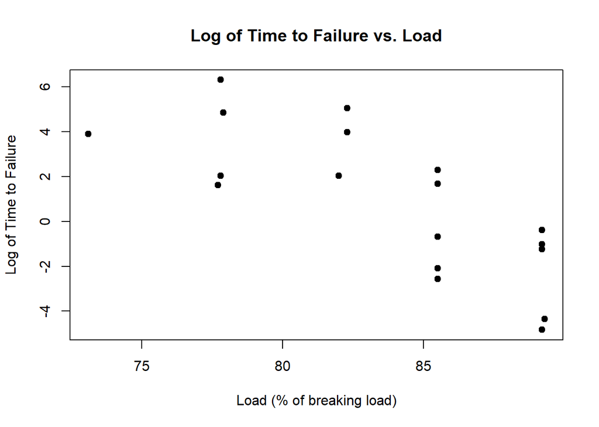

```r
ropes_data$LogTime <- log(ropes_data$Time)

plot(ropes_data$Load, ropes_data$LogTime, main = "Log of Time to Failure vs. Load",
     xlab = "Load (% of breaking load)", ylab = "Log of Time to Failure", pch = 19)
```

After taking the log of time the relationship I would say appears to be more linear.

### (c) Fit a straight line to the (x, yT ) data. Based on the linear fit, predict

the value of failure time from a load of 85%?

```r
log_time_reg <- lm(LogTime ~ Load, data = ropes_data)

coef_intercept <- log_time_reg$coefficients[[1]]
coef_slope <- log_time_reg$coefficients[[2]]

cat("Regression equation for the transformed data:\n")
```

```
## Regression equation for the transformed data:
```

```r
cat("log(Time) =", round(coef_intercept, 4), "+", round(coef_slope, 4), "× Load\n")
```

```
## log(Time) = 42.1482 + -0.4932 × Load
```

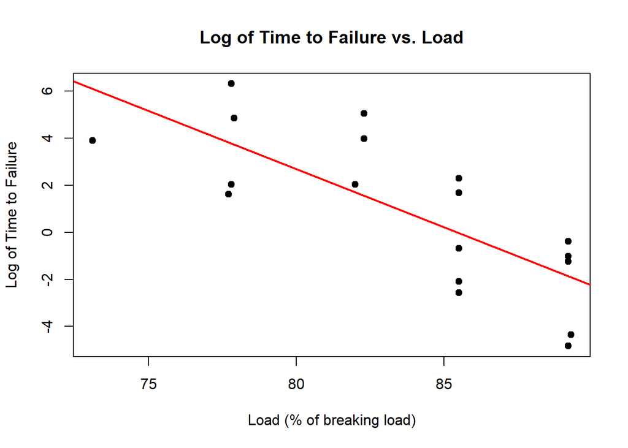

```r
plot(ropes_data$Load, ropes_data$LogTime, main = "Log of Time to Failure vs. Load",
     xlab = "Load (% of breaking load)", ylab = "Log of Time to Failure", pch = 19)

abline(log_time_reg, col = "red", lwd = 2)
```

```r
predicted_log_time <- coef_intercept + coef_slope * 85
cat("Predicted log for a load of 85%:", round(predicted_log_time, 4), "\n")
```

```
## Predicted log for a load of 85%: 0.2221
```

```r
predicted_time <- exp(predicted_log_time)
cat("Predicted failure time for a load of 85%:", round(predicted_time, 4), "\n")
```

```
## Predicted failure time for a load of 85%: 1.2487
```